# What Makes a BBC News Category? A Tidyverse-Based Exploration of 2,225 Articles

Author

Viktor Taseski

Published

May 12, 2026

# 1 Introduction

News classification is one of the canonical problems of natural-language processing: given a piece of text, decide whether it belongs to *business*, *entertainment*, *politics*, *sport* or *tech*. Long before deep neural networks made this easy, journalists, librarians and computer scientists asked a simpler question that still motivates modern systems: **do news articles in different categories actually look different on the surface?**

This project takes one of the most-cited public benchmarks in the area, the **BBC News dataset** [@greene2006], and answers that question with a strictly tidyverse workflow. Concretely, we will:

- describe the structure of the corpus (2,225 articles in five categories);
- derive new features — length of the title, length of the body, share of category-specific vocabulary — using `mutate`, `filter`, `summarise` and `inner_join` chained through the pipe `|>`;
- visualise the resulting patterns with three distinct `ggplot2` charts plus a heat-map of the most distinctive words per category;
- draw conclusions about which surface features carry the most discriminative power.

The deliverable is a single self-contained Quarto report, intended as a university-level demonstration of the tidyverse workflow [@wickham2019; @quarto2024].

# 2 Presentation of the data

The data was downloaded from Kaggle [@kaggle_bbc] and stored as a single tab-separated file (`bbc-news-data.csv`). Each row is one news article collected from the BBC News website between 2004 and 2005.

```r
news <- readr::read_tsv("bbc-news-data.csv", show_col_types = FALSE)

dim(news)
```

```
[1] 2225    4
```

```r
glimpse(news)
```

```
Rows: 2,225
Columns: 4
$ category <chr> "business", "business", "business", "business", "business", "…
$ filename <chr> "001.txt", "002.txt", "003.txt", "004.txt", "005.txt", "006.t…
$ title    <chr> "Ad sales boost Time Warner profit", "Dollar gains on Greensp…
$ content  <chr> "Quarterly profits at US media giant TimeWarner jumped 76% to…
```

```r
news |>
  head(5) |>
  mutate(content = str_trunc(content, 90)) |>
  knitr::kable(caption = "First five rows of the raw BBC News data frame.")
```

First five rows of the raw BBC News data frame.

| category | filename | title | content |
| --- | --- | --- | --- |
| business | 001.txt | Ad sales boost Time Warner profit | Quarterly profits at US media giant TimeWarner jumped 76% to $1.13bn (£600m) for the th… |
| business | 002.txt | Dollar gains on Greenspan speech | The dollar has hit its highest level against the euro in almost three months after the … |
| business | 003.txt | Yukos unit buyer faces loan claim | The owners of embattled Russian oil giant Yukos are to ask the buyer of its former prod… |
| business | 004.txt | High fuel prices hit BA’s profits | British Airways has blamed high fuel prices for a 40% drop in profits. Reporting its r… |
| business | 005.txt | Pernod takeover talk lifts Domecq | Shares in UK drinks and food firm Allied Domecq have risen on speculation that it could… |

The data frame contains four columns:

| Column | Type | Unit / domain |
| --- | --- | --- |
| `category` | character | One of `business`, `entertainment`, `politics`, `sport`, `tech`. |
| `filename` | character | Original BBC text-file name, e.g. `001.txt`. Identifies the article. |
| `title` | character | Headline of the article (free text, English). |
| `content` | character | Full body of the article (free text, English, up to ~4,400 words). |

To enrich the analysis we also load a small auxiliary table that we will later `inner_join` to the articles. It groups the five categories into broader newsroom sections.

```r
category_meta <- readr::read_csv("category_meta.csv", show_col_types = FALSE)
category_meta |> knitr::kable(caption = "Auxiliary table mapping each category to its broader BBC newsroom section.")
```

Auxiliary table mapping each category to its broader BBC newsroom section.

| category | description | broad_section |
| --- | --- | --- |
| business | Markets, companies, finance, economy | Hard news |
| entertainment | Film, music, celebrities, awards | Soft news |
| politics | Government, parties, elections, policy | Hard news |
| sport | Football, rugby, athletics, tennis | Sports |
| tech | Technology, gadgets, internet, science | Technology |

# 3 Transformation of data

We now build three derived tables. Each one exercises a different part of the tidyverse: feature engineering, grouped aggregation and a relational join.

## 3.1 Table 1 – Feature engineering with `mutate` and a user-defined function

We add three new columns: the number of words in the title, the number of words in the body, and a coarse “long article” flag.

```r
news_features <- news |>
  mutate(
    title_words   = count_words(title),
    content_words = count_words(content),
    long_article  = if_else(content_words >= 500, "long", "short")
  )

news_features |>
  select(category, filename, title_words, content_words, long_article) |>
  head(8) |>
  knitr::kable(caption = "Engineered features for the first eight articles.")
```

Engineered features for the first eight articles.

| category | filename | title_words | content_words | long_article |
| --- | --- | --- | --- | --- |
| business | 001.txt | 6 | 415 | short |
| business | 002.txt | 5 | 379 | short |
| business | 003.txt | 6 | 258 | short |
| business | 004.txt | 6 | 400 | short |
| business | 005.txt | 5 | 260 | short |
| business | 006.txt | 4 | 180 | short |
| business | 007.txt | 7 | 277 | short |
| business | 008.txt | 6 | 315 | short |

**Reading the table.** `count_words` is our user-defined helper that uses `str_squish` (collapses whitespace) and `str_count("\\S+")` (counts non-whitespace runs). The `long_article` column will let us slice the corpus by article length later on.

## 3.2 Table 2 – Grouped summary with `group_by` + `summarise`

Now we aggregate per category to get a one-row-per-category profile of the corpus.

```r
category_summary <- news_features |>
  group_by(category) |>
  summarise(
    n_articles           = n(),
    avg_title_words      = mean(title_words)   |> round(2),
    avg_content_words    = mean(content_words) |> round(1),
    median_content_words = median(content_words),
    sd_content_words     = sd(content_words)   |> round(1),
    pct_long             = mean(long_article == "long") |> percent(accuracy = 0.1)
  ) |>
  arrange(desc(n_articles))

category_summary |>
  knitr::kable(caption = "Per-category summary statistics.")
```

Per-category summary statistics.

| category | n_articles | avg_title_words | avg_content_words | median_content_words | sd_content_words | pct_long |
| --- | --- | --- | --- | --- | --- | --- |
| sport | 511 | 4.89 | 324.4 | 282.0 | 188.1 | 13.3% |
| business | 510 | 5.40 | 323.5 | 292.0 | 135.8 | 8.2% |
| politics | 417 | 5.09 | 448.9 | 434.0 | 300.2 | 31.7% |
| tech | 401 | 5.27 | 497.4 | 441.0 | 239.8 | 39.7% |
| entertainment | 386 | 5.42 | 325.2 | 256.5 | 261.9 | 11.1% |

## 3.3 Table 3 – Relational join with `inner_join`

Finally we use `inner_join` to attach the broader-section labels from `category_meta`, then re-aggregate at the section level.

```r
section_summary <- news_features |>
  inner_join(category_meta, by = "category") |>
  group_by(broad_section) |>
  summarise(
    n_articles        = n(),
    n_categories      = n_distinct(category),
    avg_content_words = mean(content_words) |> round(1),
    share_long        = mean(content_words >= 500) |> percent(accuracy = 0.1)
  ) |>
  arrange(desc(n_articles))

section_summary |>
  knitr::kable(caption = "Articles aggregated to the broader newsroom-section level.")
```

Articles aggregated to the broader newsroom-section level.

| broad_section | n_articles | n_categories | avg_content_words | share_long |
| --- | --- | --- | --- | --- |
| Hard news | 927 | 2 | 379.9 | 18.8% |
| Sports | 511 | 1 | 324.4 | 13.3% |
| Technology | 401 | 1 | 497.4 | 39.7% |
| Soft news | 386 | 1 | 325.2 | 11.1% |

# 4 Exploratory data analysis

## 4.1 Plot 1 – Bar chart: corpus composition

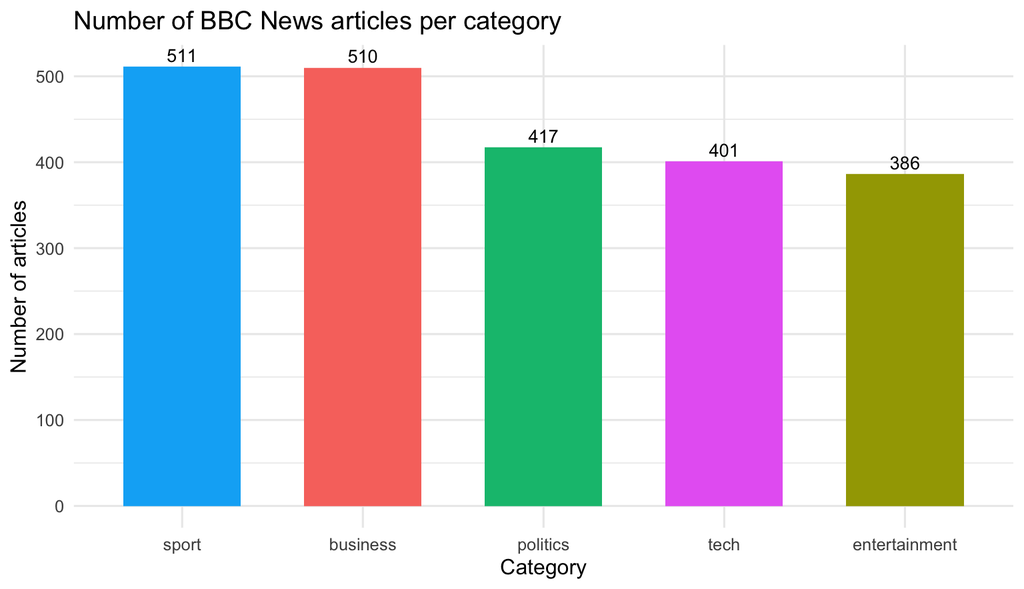

Number of BBC News articles per category.

```r
news_features |>
  count(category) |>
  ggplot(aes(x = fct_reorder(category, n, .desc = TRUE), y = n, fill = category)) +
  geom_col(width = 0.65) +
  geom_text(aes(label = n), vjust = -0.4, size = 3.6) +
  labs(
    title = "Number of BBC News articles per category",
    x = "Category", y = "Number of articles"
  ) +
  theme(legend.position = "none")
```

The five classes are reasonably balanced — the largest (*sport*, 511) is only ~32 % bigger than the smallest (*entertainment*, 386). A trained classifier will not need much resampling; the chart also tells us the prior probability the BBC editorial team itself assigned to each beat over the period covered.